# Lab 05: Colors with Animal Sounds

Using Colour Palettes in R

Arvind Venkatadri

# 1 Introduction

This RMarkdown document is part of the Generic Skills Component (GSK) of the Course of the Foundation Studies Programme at Srishti Manipal Institute of Art, Design, and Technology, Bangalore India. The material is based on *A Layered Grammar of Graphics* by Hadley Wickham. The course is meant for First Year students pursuing a Degree in Art and Design.

The intent of this GSK part is to build Skill in coding in R, and also appreciate R as a way to metaphorically visualize information of various kinds, using predominantly geometric figures and structures.

All RMarkdown files combine code, text, web-images, and figures developed using code. Everything is text; code chunks are enclosed in **fences** (```)

(This Lab has been taken from Allison Hill’s blogdown tutorial)

# 2 Goals

- (Re)Understand different kinds of data variables
- Appreciate how they can be identified based on the *Interrogative Pronouns* they answer to
- Understand how each kind of variable lends itself to a specific choice of **colour scale** in the data visualization.

# 3 Pedagogical Note

The method followed will be based on [PRIMM](https://blogs.kcl.ac.uk/cser/2017/09/01/primm-a-structured-approach-to-teaching-programming/):

- **PREDICT** Inspect the code and guess at what the code might do, **write predictions**
- **RUN** the code provided and check what happens
- **INFER** what the `parameters` of the code do and **write comments to explain**. What bells and whistles can you see?
- **MODIFY** the `parameters` code provided to understand the `options` available. **Write comments** to show what you have aimed for and achieved.
- **MAKE** : take an idea/concept of your own, and graph it.

# 4 Data

For today, we’ll play with the `sounds` dataset. This data was derived from the R package [`wordbankr`](http://langcog.github.io/wordbankr/), an R interface to access [Wordbank](http://wordbank.stanford.edu)- an open source database of children’s vocabulary development. The tool used to measure children’s language and communicative development in this database is the [MacArthur-Bates Communicative Development Inventories (MB-CDI)](http://mb-cdi.stanford.edu). The MD-CDI is a parent-reported questionnaire.

```r
sounds <- read_csv("./data/animal_sounds_summary.csv")
```

Here is a glimpse of the data:

```r
glimpse(sounds)
```

```
Rows: 33
Columns: 7
$ age             <dbl> 8, 8, 8, 9, 9, 9, 10, 10, 10, 11, 11, 11, 12, 12, 12, ~
$ sound           <chr> "cockadoodledoo", "meow", "woof woof", "cockadoodledoo~
$ kids_produce    <dbl> 1, 0, 3, 0, 2, 2, 0, 5, 4, 0, 5, 12, 0, 12, 28, 9, 125~
$ kids_understand <dbl> 3, 10, 12, 2, 21, 22, 9, 41, 40, 4, 36, 32, 16, 59, 59~
$ kids_respond    <dbl> 35, 35, 35, 91, 93, 93, 139, 145, 143, 94, 94, 94, 141~
$ prop_produce    <dbl> 0.02857143, 0.00000000, 0.08571429, 0.00000000, 0.0215~
$ prop_understand <dbl> 0.08571429, 0.28571429, 0.34285714, 0.02197802, 0.2258~
```

Note that the unit of observation here is one-row-per-age-group/animal sound.

Variables you need for this lab:

- `age`: child age in months
- `sound`: a string describing a type of animal sound
- `kids_produce`: the number of parents who answered “yes, my child produces this animal sound” (note that if the child produces a sound it is assumed that they understand it as well)
- `kids_respond`: the number of parents who responded to this question at all
- `prop_produce`: the proportion of kids whose parents endorsed that their child produces this animal sound, out of all questionnaires administered (i.e., `kids_produce / kids_respond`)

Other variables in this dataset:

- `kids_understand`: the number of parents who answered “yes, my child understands what this animal sound means” (note that a child can understand the sound but not produce it)
- `prop_understand`: the proportion of kids whose parents endorsed that their child understands this animal sound, out of all questionnaires administered (i.e., `kids_understand / kids_respond`)

# 5 Colour vs fill aesthetic

Fill and colour scales in ggplot2 can use the same palettes. Some shapes such as lines only accept the colour aesthetic, while others, such as polygons, accept both colour and fill aesthetics. In the latter case, the colour refers to the border of the shape, and the fill to the interior.

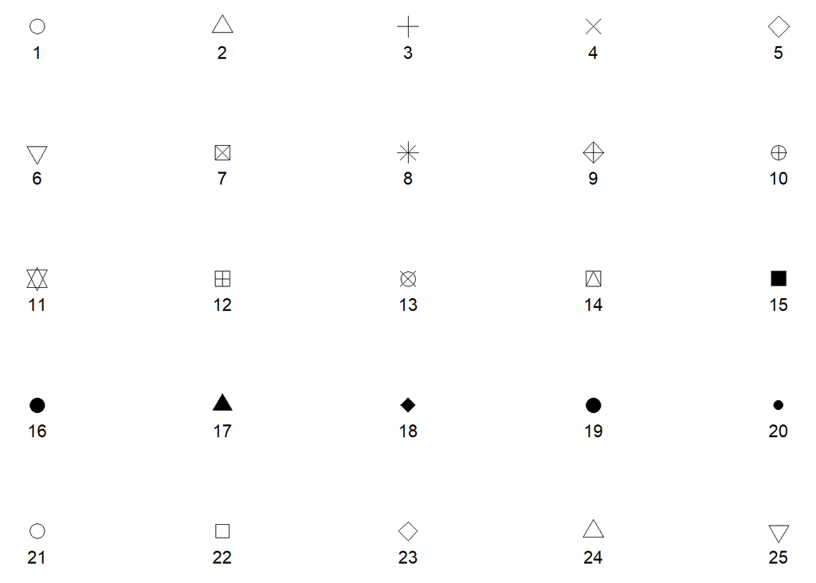

All symbols have a foreground colour, so if we add `color = "navy"`, they all are affected.

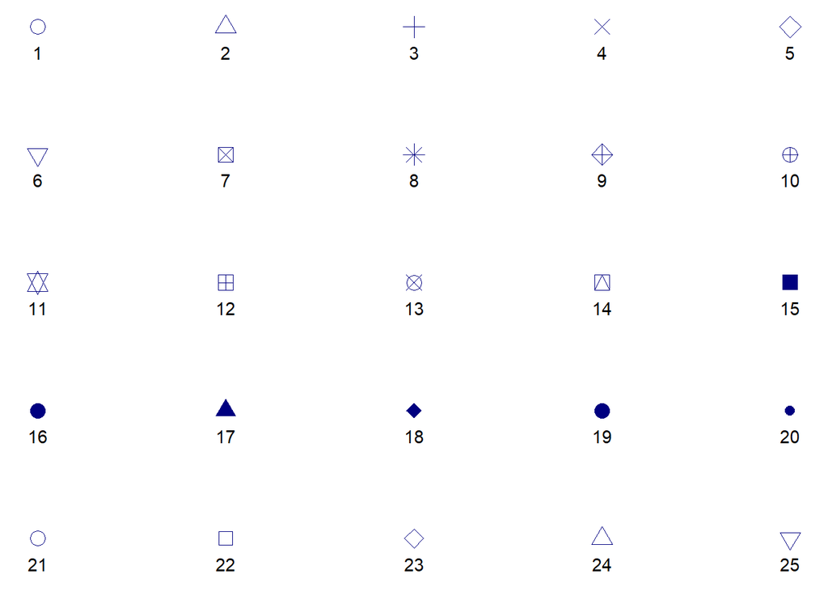

```r
s + geom_point(aes(shape = z), size = 4, colour = "navy")
```

While all symbols have a foreground colour, symbols 21-25 also take a background colour (fill). So if we add `fill = "orchid"`, only the last row of symbols are affected.

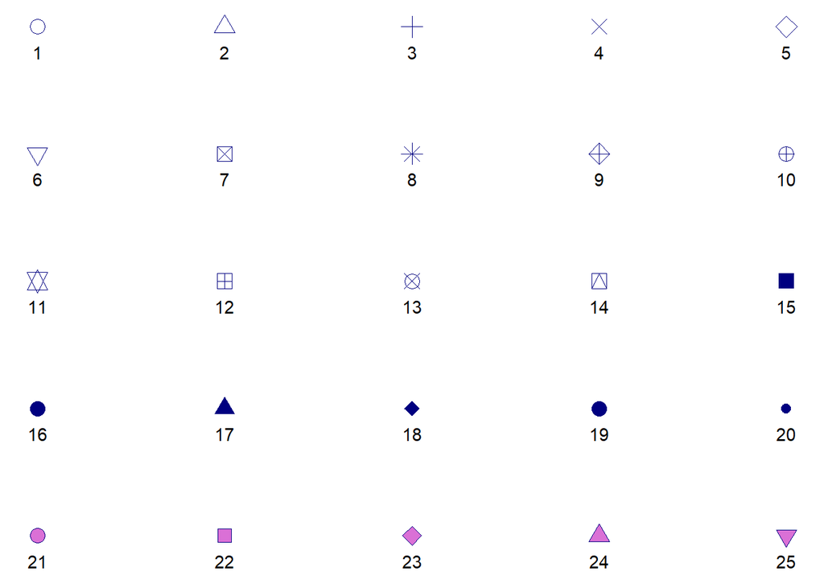

```r
s + geom_point(aes(shape = z), size = 4, colour = "navy", fill = "orchid")
```

# 6 Discrete vs continuous variables

[WHAT IS THE DIFFERENCE BETWEEN CATEGORICAL, ORDINAL AND INTERVAL VARIABLES?](https://stats.idre.ucla.edu/other/mult-pkg/whatstat/what-is-the-difference-between-categorical-ordinal-and-interval-variables/)

In order to use color with your data, most importantly, you need to know if you’re dealing with discrete or continuous variables.

## 6.1 Discrete color palettes

Discrete color palettes work best when you want to color by a qualitative variable. Qualitative variables tend to be either **categorical** or **ordinal**. Different variables can be qualitative or quantitative depending on context.

In this dataset, `sound` is a categorical variable with 3 possible values:

```r
sounds %>%
  distinct(sound) %>%
  knitr::kable()
```

| sound |
| --- |
| cockadoodledoo |
| meow |
| woof woof |

We could map arbitrary numbers onto each of these sounds, like 1, 2, and 3- but the numbers still would not mean anything. **That is, there is no intrinsic ordering to these categories.** Examples of common pure categorical variables are race or ethnicity, gender, hair color, eye color, etc. Coloring by sound is used as a way to *distinguish* the data for different sounds from each other (read more here: http://serialmentor.com/dataviz/color-basics.html#color-as-a-tool-to-distinguish)

## 6.2 Continuous color palettes

Continuous color palettes work best when you want to color by a quantitative variable. Quantitative variables tend to be either ordinal or continuous. In this dataset, `age` (in months) can only take on a limited set of values:

```r
sounds %>%
  distinct(age) %>%
  pull
```

```
 [1]  8  9 10 11 12 13 14 15 16 17 18
```

However, in the following plots, we’ll treat age as a continuous variable plotted across the x-axis. In some contexts, this kind of variable could be treated as a ordinal variable. However, for color purposes, this would not ideal here since there are 11 “categories” (see http://serialmentor.com/dataviz/color-pitfalls.html). Age has a natural and meaningful order: a child who is 9 months old is 1 month older than one who is 8 months old. So, we’ll use that natural ordering to our advantage and not use color to represent age as a variable. When you *do* apply a continuous color palette, you’ll want to use color to your advantage to [represent data values](http://serialmentor.com/dataviz/color-basics.html#color-to-represent-data-values).

# 7 Know your data

**Challenge #1:**

- How many variables?
  - Which variables are continuous?
  - Which ones are categorical or ordinal?
- How many total kids do we have data for?
- How many ages (in months)?
  - How many kids per age?
- How many types of animal sounds? What are they?

Let’s start just by getting a feel for how many kids produce each kind of sound, across the full age range. We could make a table:

```r
sounds %>%
  group_by(sound) %>%
  summarize(total_produce = sum(kids_produce)) %>%
  knitr::kable()
```

| sound | total_produce |
| --- | --- |
| cockadoodledoo | 148 |
| meow | 681 |
| woof woof | 940 |

Or we could make a simple bar plot:

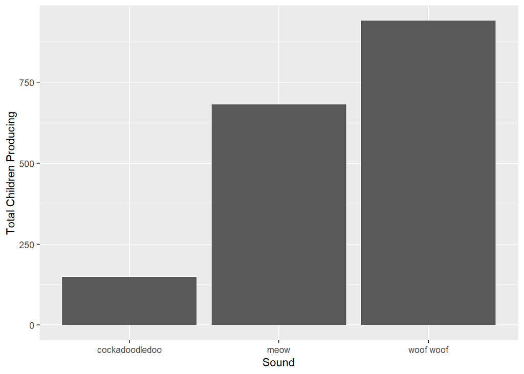

```r
ggplot(sounds, aes(x = sound, y = kids_produce)) +
  geom_col() +
  labs(x = "Sound", y = "Total Children Producing")
```

For this kind of plot, we don’t really need color. What if we want to see how the number of kids who produce each sound varies by age? We’ll change the x-axis to age and instead `facet_wrap` by `sound`, and make the y-axis a proportion instead of counts.

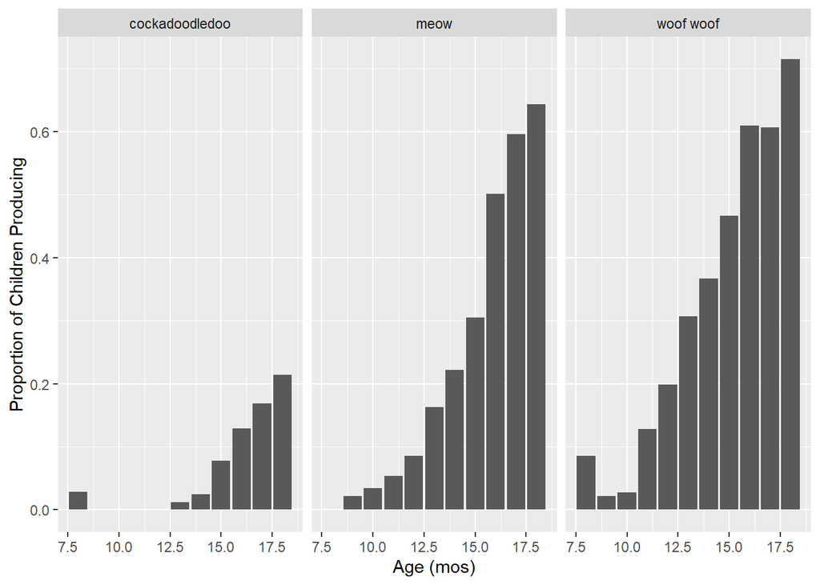

```r
ggplot(sounds, aes(x = age, y = prop_produce)) +
  geom_col() +
  labs(x = "Age (mos)", y = "Proportion of Children Producing") +
  facet_wrap(~sound)
```

The bar geom makes this a little hard to read and compare across facets though. Let’s try points instead.

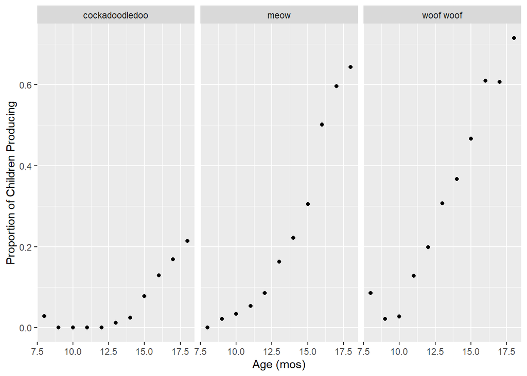

```r
ggplot(sounds, aes(x = age, y = prop_produce)) +
  geom_point() +
  labs(x = "Age (mos)", y = "Proportion of Children Producing") +
  facet_wrap(~sound)
```

That is a little better! Facets allow us to parse the relationship between two quantitative variables (here, age and proportion of kids producing) by a qualitative variable (here, type of sound). Another way we could do this, instead of facetting, is to use color. This would make it easier to compare proportions at each age.

# 8 Discrete colors

Let’s start with a base plot with age (in months) along the x-axis and the proportion of children producing each word along the y-axis, using points as the geometric object. Set the size of the points to 2 and change the x- and y-axis labels to “Age (months)” and “Proportion of Children Producing”, respectively.

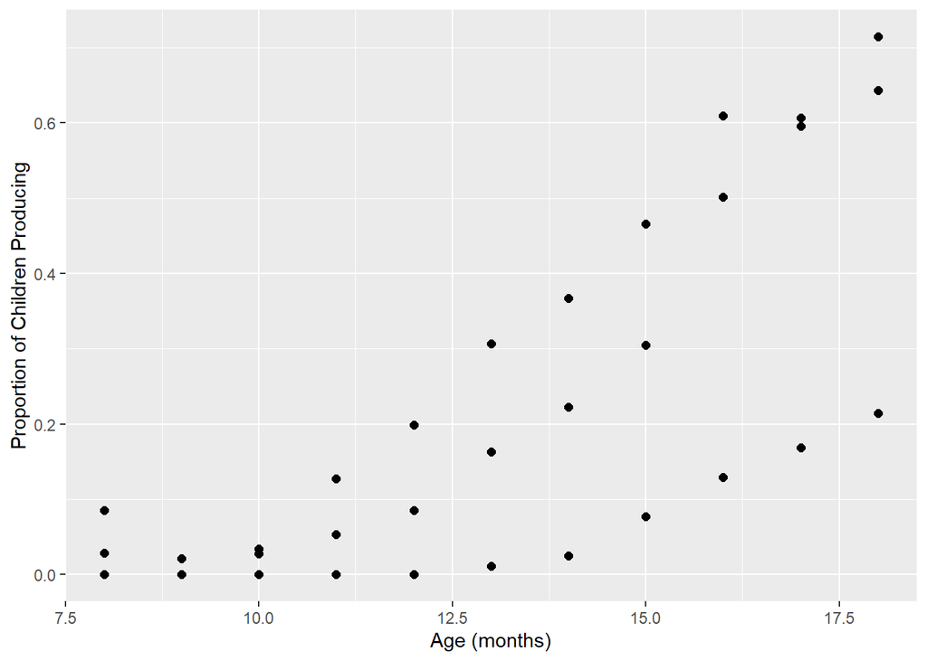

```r
ggplot(sounds, aes(x = age, y = prop_produce)) +
  geom_point(size = 2) +
  labs(x = "Age (months)", y = "Proportion of Children Producing")
```

## 8.1 Default discrete palette

**Challenge #2:**

Take the plot we just made, and edit the code to map the color of the points to the type of sound produced *at the geom level*. The colors that show up are the default discrete palette in `ggplot2`.

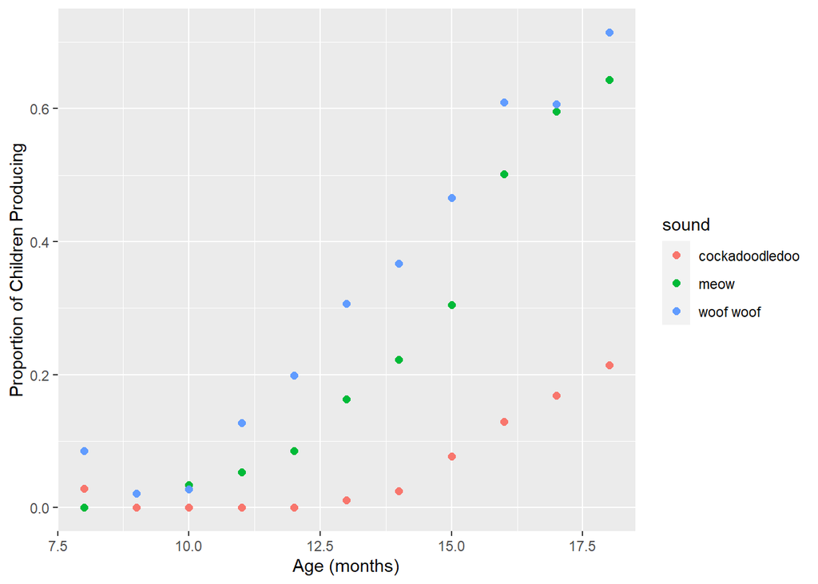

```r
ggplot(sounds, aes(x = age, y = prop_produce)) +
  geom_point(aes(color = sound), size = 2) +
  labs(x = "Age (months)", y = "Proportion of Children Producing")
```

**Challenge #3:**

Try adding `geom_line()` to this plot to connect the dots. Does this look right? Use `?geom_line` to figure out how this geom connects the dots by default, and which aesthetic can be used to connect cases together. Try editing your code to draw 3 black lines- one for each sound.

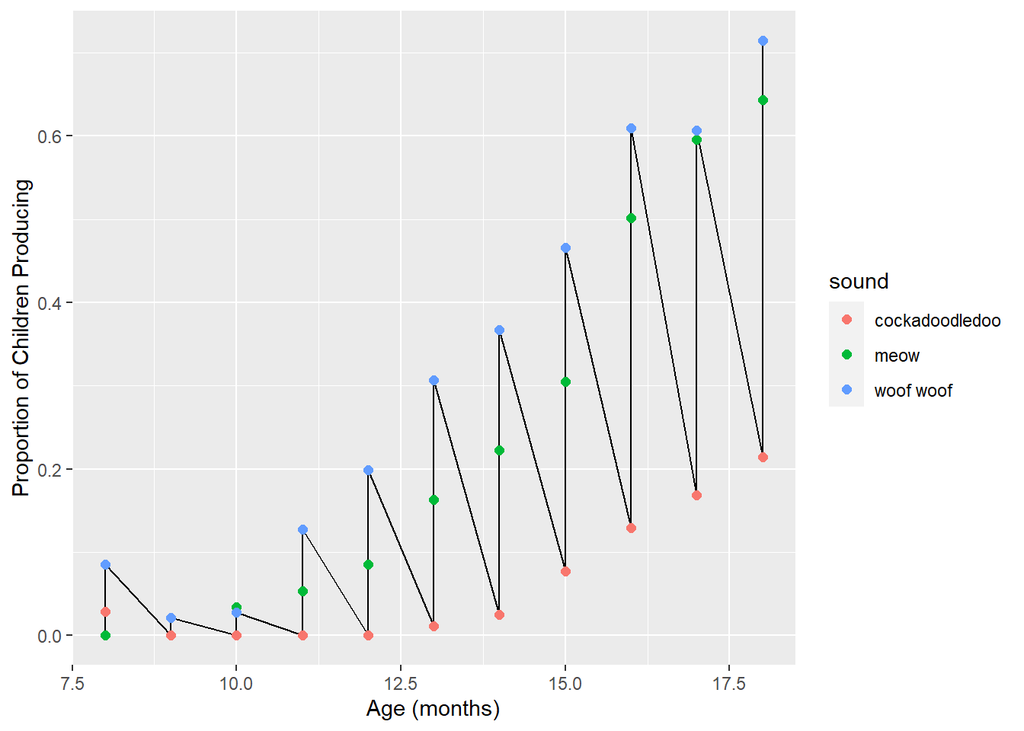

```r
# Does this look right? no!
ggplot(sounds, aes(x = age, y = prop_produce)) +
  geom_line() +
  geom_point(aes(color = sound), size = 2) +
  labs(x = "Age (months)", y = "Proportion of Children Producing")
```

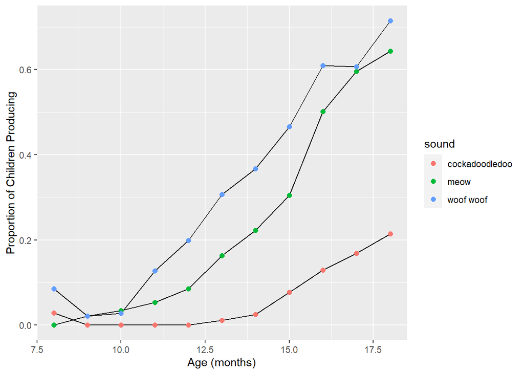

```r
# A possible solution
ggplot(sounds, aes(x = age, y = prop_produce)) +
  geom_line(aes(group = sound)) +
  geom_point(aes(color = sound), size = 2) +
  labs(x = "Age (months)", y = "Proportion of Children Producing")
```

**Challenge #4:**

Make two plots:

1. Recreate the plot above, but this time map color to the type of sound produced for both the point and line geoms. Pay attention to the order of the layers you are adding- you may wish to place `geom_line` *before* `geom_point` so the lines are always “painted” underneath the points.
2. Instead of `geom_line`, add a loess line using `geom_smooth`. Use `?geom_smooth` to figure out how to get rid of the grey standard error ribbon. You may also want to increase the line width.

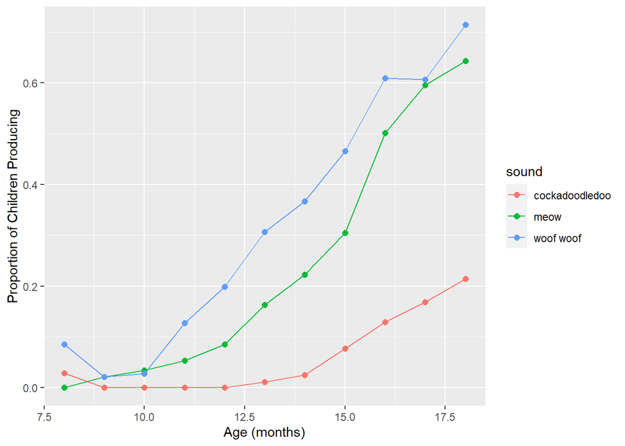

```r
# Does this look right? yes!
ggplot(sounds, aes(x = age, y = prop_produce, color = sound)) +
  geom_line() +
  geom_point(size = 2) +
  labs(x = "Age (months)", y = "Proportion of Children Producing")
```

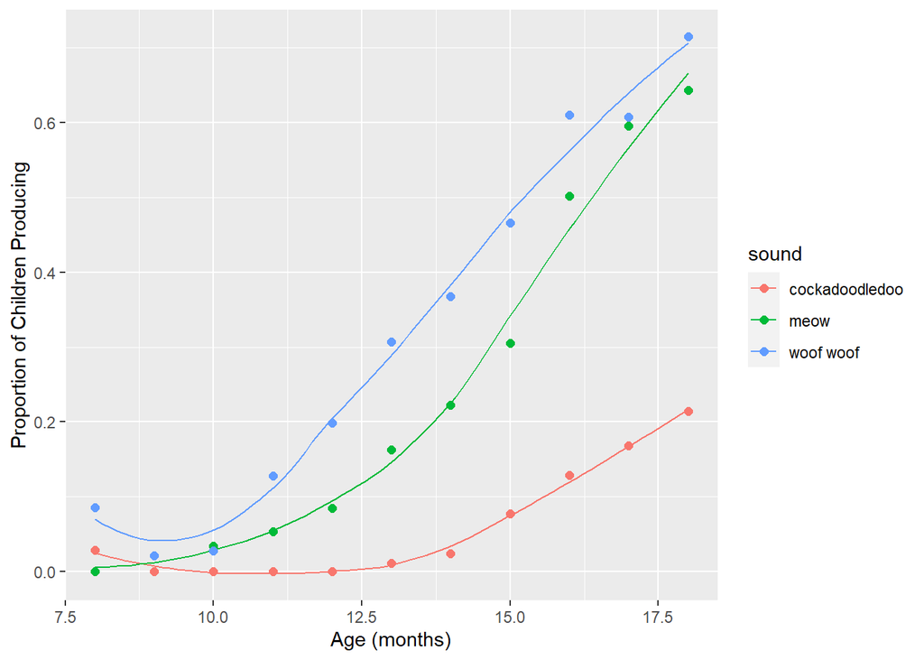

```r
ggplot(sounds, aes(x = age,
                         y = prop_produce,
                         color = sound)) +
  geom_smooth(se = FALSE, lwd = .5) +
  geom_point(size = 2)  +
  labs(x = "Age (months)", y = "Proportion of Children Producing")
```

Why does this work? To tell `geom_line` how to connect your dots, you can either:

- Map the `group` aesthetic (so `aes(group = sound)`), or
- Map the `color` aesthetic globally (`aes(color = sound)`.

Because `geom_line` understands the `color` aesthetic, it will try to draw separate lines for each color. Here that translates to three lines, one for each sound, which is what we want!

## 8.2 Brief aside: factors

At this point, our plot is looking pretty good. But you may have noticed that the legend order doesn’t match the lines. We can fix that using the [`forcats` package](http://forcats.tidyverse.org), which is `for` `cat`egorical variables. There are lots of functions in `forcats`, and you can install & load it separately, although `forcats` is loaded with the `tidyverse`.

```r
install.packages("forcats")
library(forcats)
```

We’ll use the `fct_reorder2` function, which works for when you have a line chart of two quantitative variables, colored by a factor variable. Let’s see the difference.

```r
sounds <- sounds %>%
  mutate(sound = as.factor(sound))

sound_traj <- ggplot(sounds, aes(x = age,
                         y = prop_produce,
                         color = fct_reorder2(sound, age, prop_produce))) +
  geom_smooth(se = FALSE, lwd = .5) +
  geom_point(size = 2) +
  labs(x = "Age (months)",
       y = "Proportion of Children Producing",
       color = "sound")
sound_traj
```

[output not shown]

MUCH BETTER! Save your plot object as `sound_traj`. Now we can start playing with the actual colors.

## 8.3 Set luminance and saturation (chromaticity)

The default qualitative palette works fine here. The addition of [`scale_color_hue`](http://ggplot2.tidyverse.org/reference/scale_hue.html) changes nothing.

```r
sound_traj +
  scale_color_hue()
```

[output not shown]

We can also change these settings within the default color palette, where the arguments are:

- `h` = range of hues to use, in [0, 360]
- `l` = luminance (lightness)
- `c` = chroma (intensity of color)

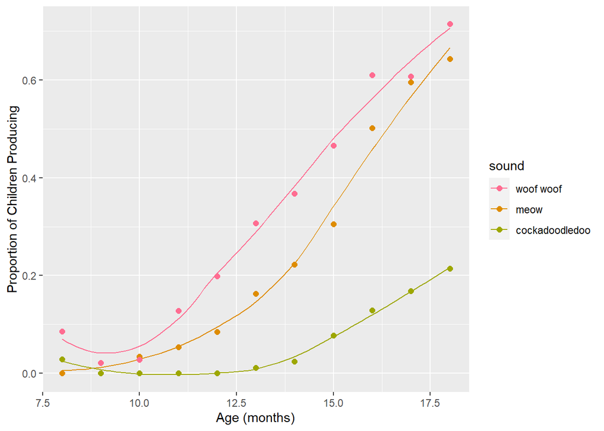

```r
# Change hue (l and c are defaults)
sound_traj +
  scale_color_hue(h = c(0, 90), l = 65, c = 100)
```

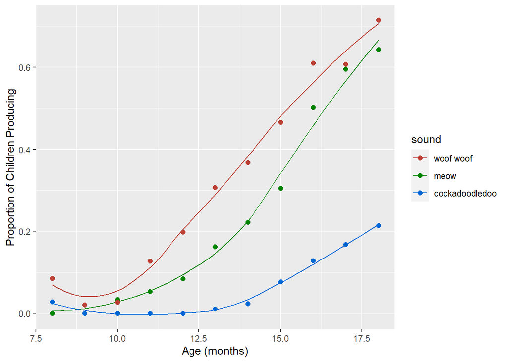

```r
# Use luminance=45, instead of default 65
sound_traj +
  scale_color_hue(l = 45)
```

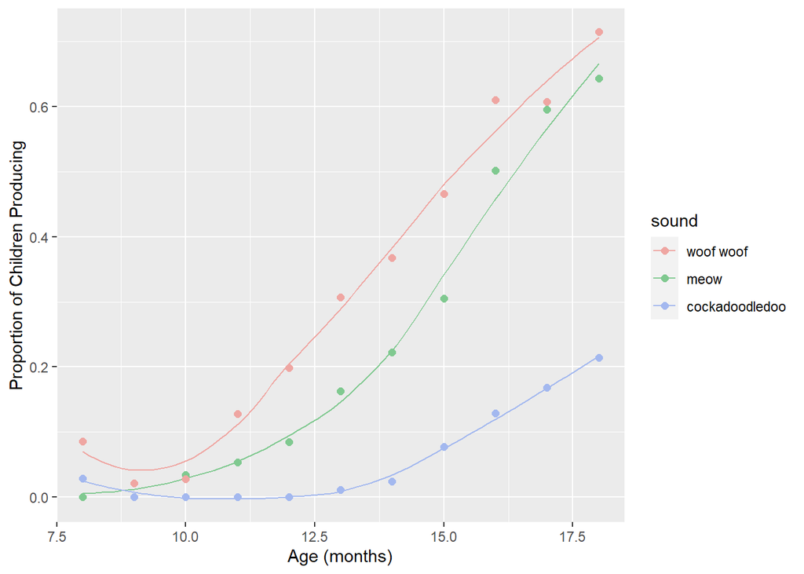

```r
# Reduce saturation (chroma) from 100 to 50, and increase luminance
sound_traj +
  scale_color_hue(l = 75, c = 50)
```

## 8.4 Set discrete colors

We can change the actual colors used by adding the layer `scale_color_manual` or `scale_fill_manual`. Confusion between which to use when is often the cause of much frustration!

To name more than one color, which you often want to do, use `c()`. In the parentheses, named colors and hex colors are always in quotes.

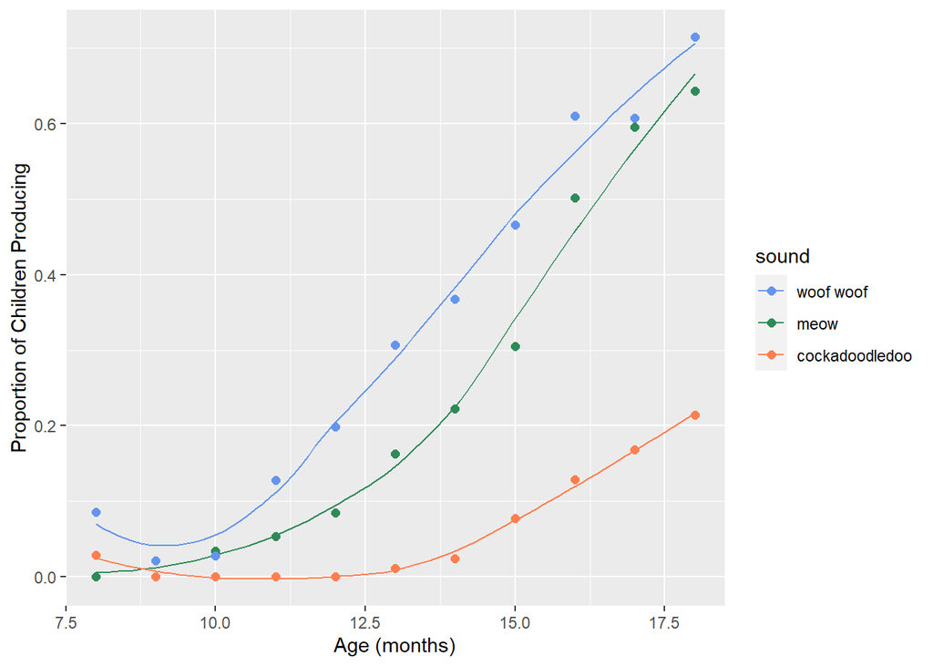

```r
sound_traj +
  scale_color_manual(values = c("cornflowerblue",
                                "seagreen", "coral"))
```

**Challenge #5:**

View the code blocks below. Copy and paste the code to run them in your own file. Why do neither of the following code blocks change the colors of the points and lines? Use your words :) *(the answer is below the challenge, but try to trouble-shoot on your own first)*

```r
ggplot(sounds, aes(x = age,
                         y = prop_produce,
                         color = fct_reorder2(sound, age, prop_produce))) +
  geom_smooth(se = FALSE, lwd = .5) +
  geom_point(size = 2) +
  labs(x = "Age (months)",
       y = "Proportion of Children Producing",
       color = "sound") +
  scale_fill_manual(values = c("cornflowerblue",
                               "seagreen", "coral"))
```

[output not shown]

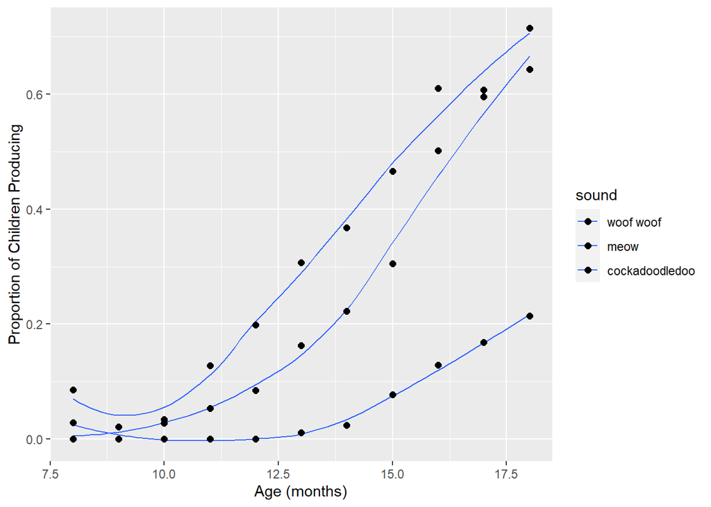

```r
ggplot(sounds, aes(x = age,
                         y = prop_produce,
                         fill = fct_reorder2(sound, age, prop_produce))) +
  geom_smooth(se = FALSE, lwd = .5) +
  geom_point(size = 2) +
  labs(x = "Age (months)",
       y = "Proportion of Children Producing",
       fill = "sound") +
  scale_fill_manual(values = c("cornflowerblue",
                               "seagreen", "coral"))
```

**Challenge #6:**

Start with this plot:

```r
sound_traj
```

Add a black outline to the points, and color the inside of the points and the lines by `sound` using the default discrete color palette. You may also wish to edit the legends on this plot: `geom_smooth` has an argument called `show.legend = FALSE`. See if you prefer the plot with this change.

If this was easy, try applying the same custom color palette to the inside of the points and to the lines.

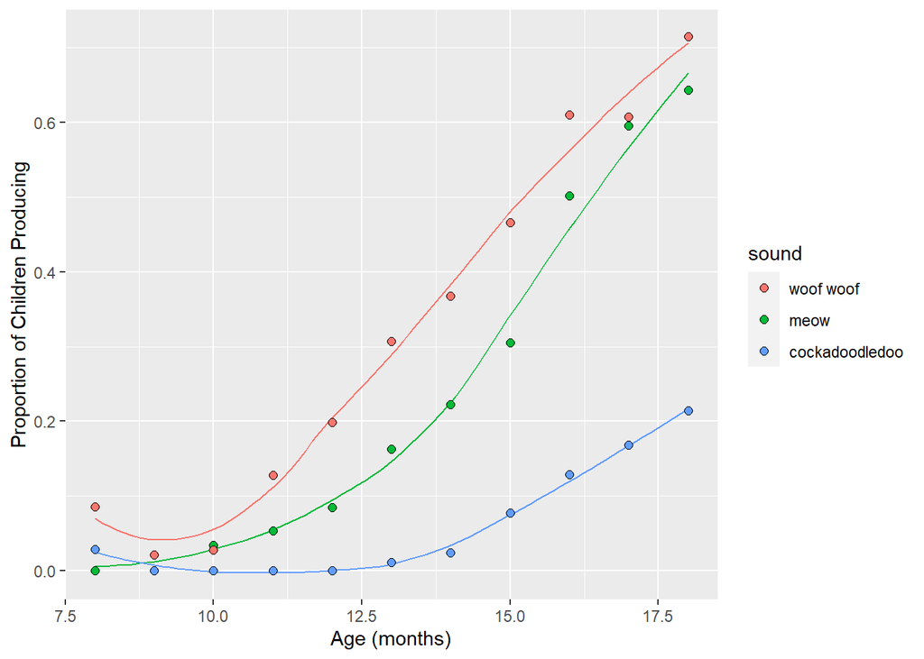

```r
ggplot(sounds, aes(x = age,
                   y = prop_produce,
                   fill = fct_reorder2(sound, age, prop_produce))) +
  geom_smooth(aes(color = fct_reorder2(sound, age, prop_produce)),
              se = FALSE, lwd = .5, show.legend = FALSE) +
  geom_point(size = 2, shape = 21) +
  labs(x = "Age (months)",
       y = "Proportion of Children Producing",
       fill = "sound")
```

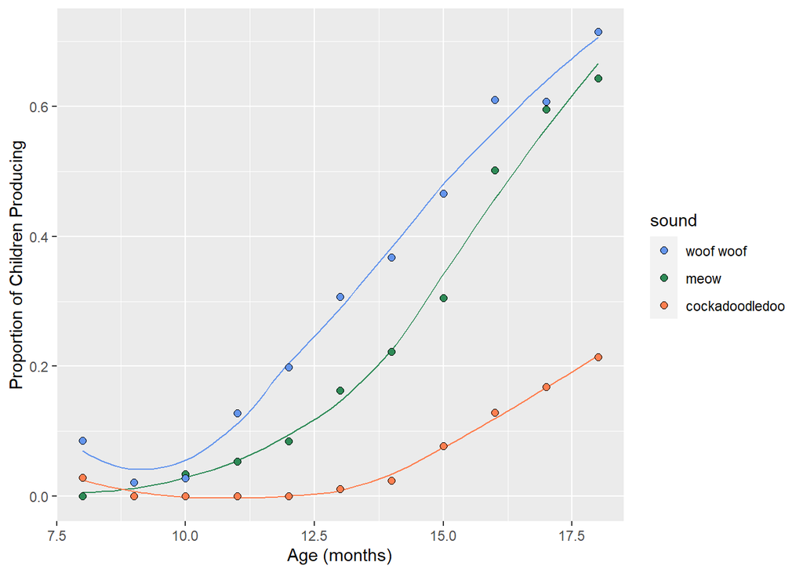

```r
ggplot(sounds, aes(x = age,
                   y = prop_produce,
                   fill = fct_reorder2(sound, age, prop_produce))) +
  geom_smooth(aes(color = fct_reorder2(sound, age, prop_produce)),
              se = FALSE, lwd = .5, show.legend = FALSE) +
  geom_point(size = 2, shape = 21) +
  labs(x = "Age (months)",
       y = "Proportion of Children Producing",
       fill = "sound") +
  scale_fill_manual(values = c("cornflowerblue",
                               "seagreen", "coral")) +
  scale_color_manual(values = c("cornflowerblue",
                               "seagreen", "coral"))
```

You can also define your color palette as a vector outside of `ggplot2`. Below, I made an object called `my_colors` outside of `ggplot2`. To use it, we call that object within the `scale_colour_manual` function.

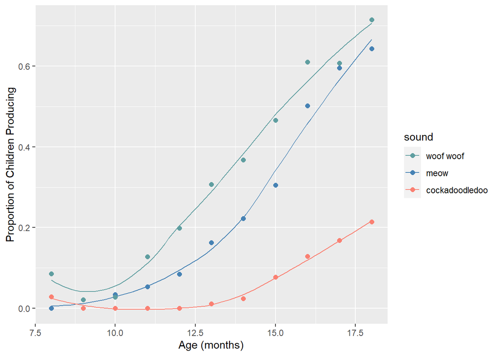

```r
my_colors <- c("cadetblue", "steelblue", "salmon") # quote color names
sound_traj +
  scale_color_manual(values = my_colors) # note: not in quotes
```

**Challenge #7:**

Define a custom color palette using hexadecimal colors (#rrggbb), and apply it using `scale_color_manual` to your `sound_traj` plot. Some basic ones are here:

https://sashat.me/2017/01/11/list-of-20-simple-distinct-colors/

Parse the hexadecimal string like so: #rrggbb, where rr, gg, and bb refer to color intensity in the red, green, and blue channels, respectively.

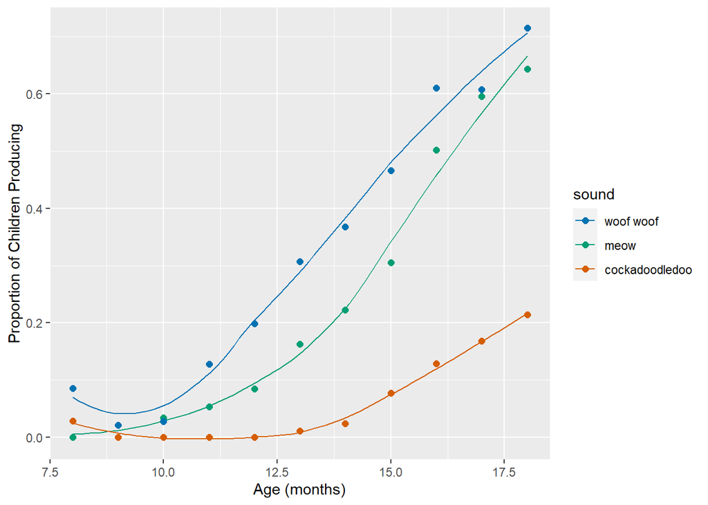

```r
# from https://github.com/mwaskom/seaborn/blob/master/seaborn/palettes.py
sb_colorblind <- c("#0072B2", "#009E73", "#D55E00",
                        "#CC79A7", "#F0E442", "#56B4E9")
sound_traj +
  scale_colour_manual(values = sb_colorblind)
```

## 8.5 Built-in discrete palettes

### 8.5.1 Colorbrewer

To use Colorbrewer palettes, you’ll need to install the `RColorBrewer` package from CRAN. This chunk of code tells you how:

```r
install.packages("RColorBrewer")
library(RColorBrewer)
```

Colorbrewer has a few qualitative palettes named: Accent, Dark2, Paired, Pastel1, Pastel2, Set1, Set2, Set3. Here is how to view them:

```r
brewer.pal(5, "Dark2") # list 5 hex colors
```

```
[1] "#1B9E77" "#D95F02" "#7570B3" "#E7298A" "#66A61E"
```

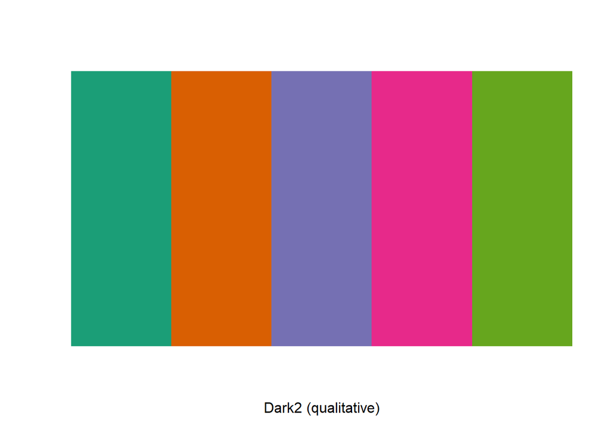

```r
display.brewer.pal(5, "Dark2") # view 5 hex colors
```

And here is how you use them:

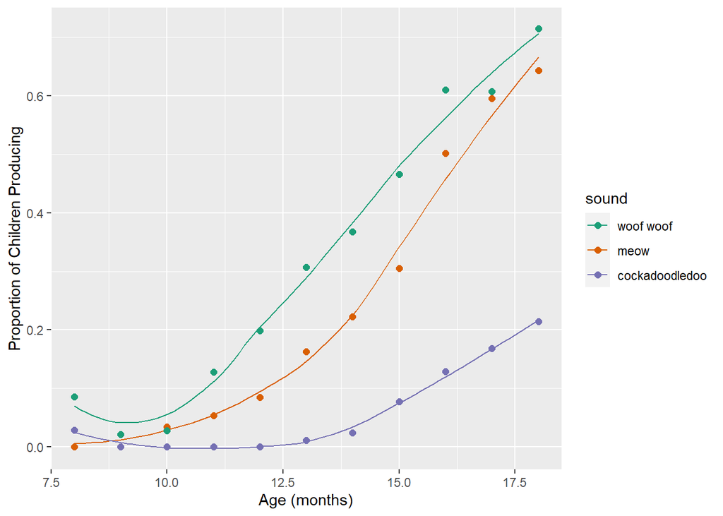

```r
sound_traj +
  scale_color_brewer(palette = "Dark2")
```

### 8.5.2 Wes Anderson palettes

My favorite! To use Wes Anderson palettes, you’ll need to install the `wesanderson` package from CRAN. This chunk of code tells you how:

```r
install.packages("wesanderson")
library(wesanderson)
```

```r
names(wes_palettes) # all the palette names
```

```
 [1] "BottleRocket1"  "BottleRocket2"  "Rushmore1"      "Rushmore"
 [5] "Royal1"         "Royal2"         "Zissou1"        "Darjeeling1"
 [9] "Darjeeling2"    "Chevalier1"     "FantasticFox1"  "Moonrise1"
[13] "Moonrise2"      "Moonrise3"      "Cavalcanti1"    "GrandBudapest1"
[17] "GrandBudapest2" "IsleofDogs1"    "IsleofDogs2"
```

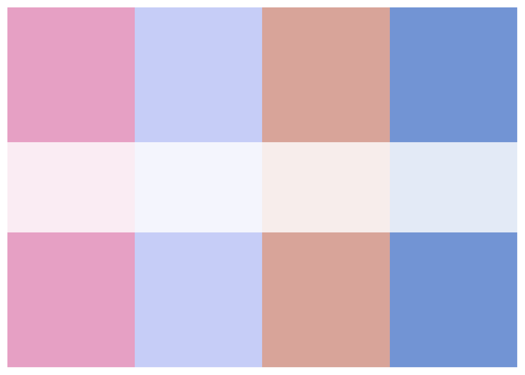

```r
wes_palette("GrandBudapest2") # view named palette
```

```r
wes_palette("GrandBudapest2")[1:4] # list first 4 hex colors
```

```
[1] "#E6A0C4" "#C6CDF7" "#D8A499" "#7294D4"
```

```r
wes_palette("GrandBudapest2")[c(1,4)] # list colors 1 and 4
```

```
[1] "#E6A0C4" "#7294D4"
```

To use these palettes, use `scale_color_manual` where `values` is set to `wes_palette("name")`. For example:

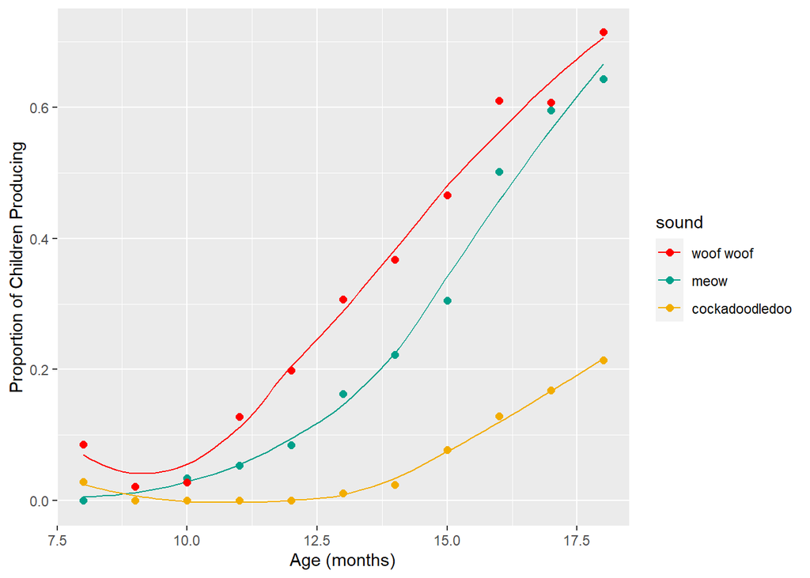

```r
sound_traj +
  scale_color_manual(values = wes_palette("Darjeeling1"))
```

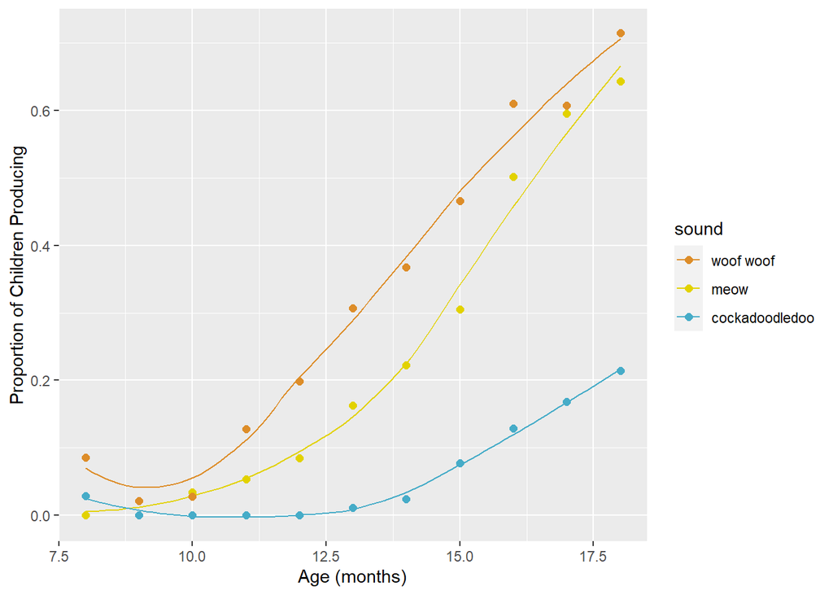

```r
sound_traj +
  scale_color_manual(values = wes_palette("FantasticFox1"))
```

**Challenge #8:**

What if you just don’t want to use the colors in the order they are in? Use a `wes_palette` of your choice. Using our code from above, try picking the last 3 colors of a palette. Add it to your `sound_traj` plot.

If this was easy, try using colors 2, 3, and 5 instead.

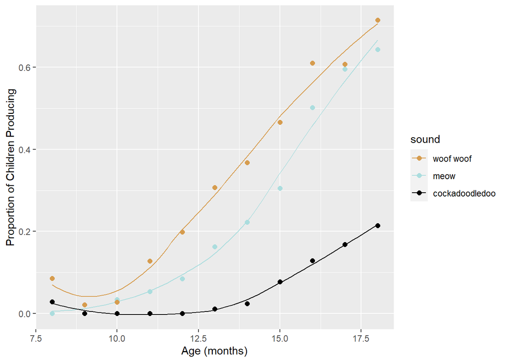

```r
sound_traj +
  scale_color_manual(values = wes_palette("Darjeeling2")[3:5])
```

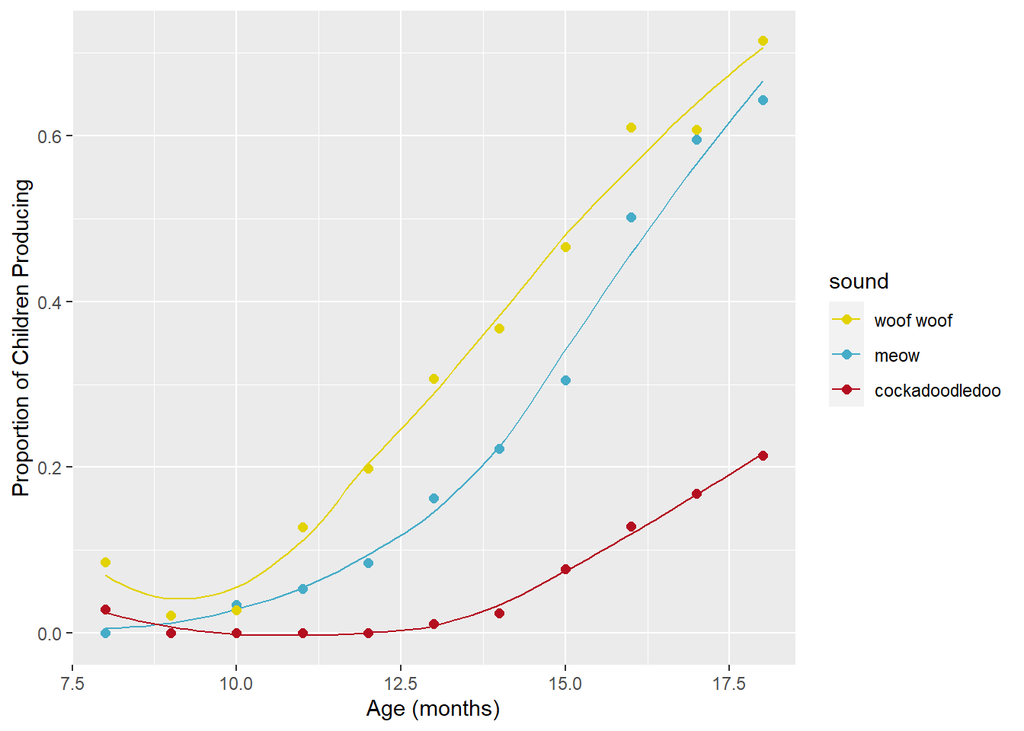

```r
sound_traj +
  scale_color_manual(values = wes_palette("FantasticFox1")[c(2, 3, 5)])
```

### 8.5.3 `ggthemes` palettes

To use these palettes, you’ll need to install the `ggthemes` package from CRAN. This chunk of code tells you how:

```r
install.packages("ggthemes")
library(ggthemes)
```

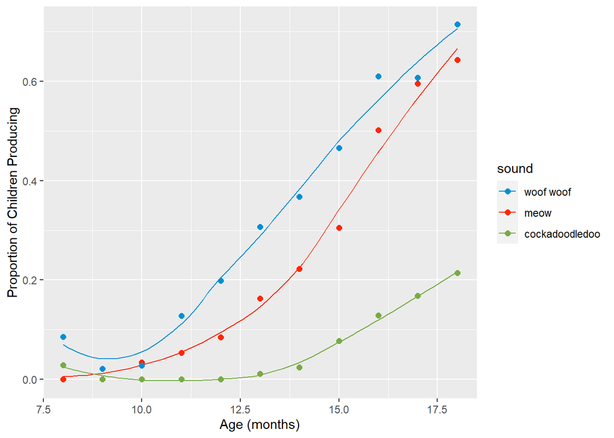

```r
sound_traj +
  scale_color_fivethirtyeight()
```

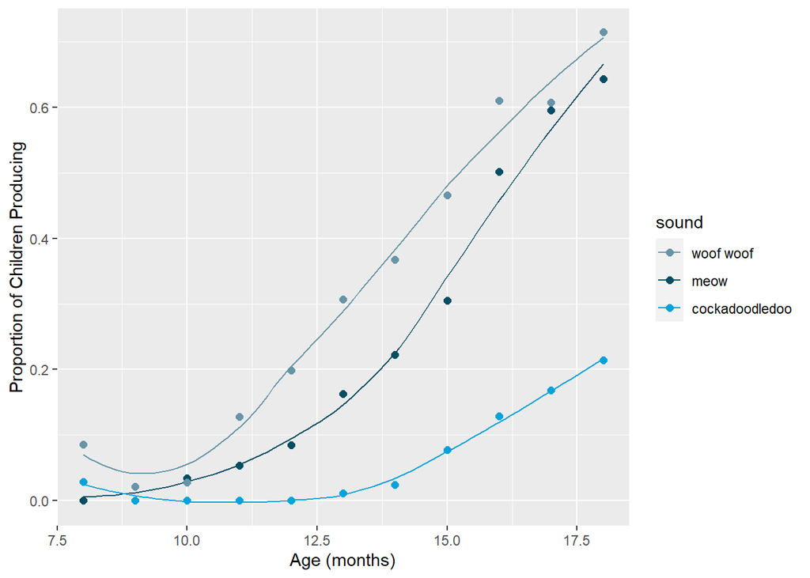

```r
sound_traj +
  scale_color_economist()
```